# 추천 알고리즘을 통한 주식 트레이딩

## 6월 수익 분석

2023년 상반기가 끝났습니다.

상반기 마지막달이었던 6월 주식 보유종목을 분석해보고 살펴보겠습니다.

```python
import pandas as pd

_6stocks_df = pd.read_csv('./6월 보유종목.csv')
_6momentum_df = pd.read_csv('./6월 모멘텀.csv')
_7stocks_df = pd.read_csv('./7월 보유종목.csv')
```

```python
_6momentum_df['6_profit'] = _6momentum_df.m30.astype(float)
```

```python
_6stocks_df = pd.merge(_6stocks_df, _6momentum_df[['code', '6_profit']], on='code', how='left')
_6stocks_df
```

|  | dt | code | m30 | m30_rank | N | name | OIGR | OIGR_rank | PBR | PBR_rank | ... | ROA_rank | ROE | ROE_rank | RR | RR_rank | sector | sector_pbr | sector_per | total_rank | 6_profit |
| --- | --- | --- | --- | --- | --- | --- | --- | --- | --- | --- | --- | --- | --- | --- | --- | --- | --- | --- | --- | --- | --- |
| 0 | 20230601 | 6120 | 1.127213 | 146.0 | 281 | SK디스커버리 | 387.09 | 23.0 | 0.24 | 3.0 | ... | 147.0 | 16.34 | 64.0 | 3432.8 | 55.0 | 석유와가스 | 0.525000 | 14.730000 | 440.0 | 1.022254 |
| 1 | 20230601 | 7340 | 1.092084 | 224.0 | 254 | DN오토모티브 | 370.22 | 24.0 | 0.73 | 96.0 | ... | 141.0 | 22.81 | 39.0 | 23085.5 | 2.0 | 자동차부품 | 0.808077 | 41.617692 | 548.0 | 1.140766 |
| 2 | 20230601 | 7860 | 1.126329 | 151.0 | 599 | 서연 | 125.36 | 62.0 | 0.34 | 16.0 | ... | 180.0 | 13.14 | 105.5 | 4537.4 | 41.0 | 자동차부품 | 0.808077 | 41.617692 | 561.5 | 1.010757 |
| 3 | 20230601 | 13310 | 1.528070 | 17.0 | 413 | 아진산업 | 232.98 | 37.0 | 0.81 | 121.0 | ... | 163.0 | 14.49 | 85.0 | 1125.6 | 186.0 | 자동차부품 | 0.808077 | 41.617692 | 640.0 | 1.177196 |
| 4 | 20230601 | 18500 | 1.323591 | 31.0 | 1053 | 동원금속 | 1102.99 | 7.0 | 0.77 | 110.0 | ... | 171.0 | 48.51 | 6.0 | 146.7 | 305.0 | 자동차부품 | 0.808077 | 41.617692 | 639.0 | 2.369816 |
| 5 | 20230601 | 35080 | 1.436828 | 20.0 | 273 | 그래디언트 | 486.16 | 18.0 | 0.48 | 33.5 | ... | 9.0 | 74.59 | 1.0 | 1344.4 | 157.0 | 인터넷과카탈로그소매 | 1.855000 | 11.220000 | 239.5 | 0.933184 |
| 6 | 20230601 | 43370 | 1.239222 | 49.0 | 420 | 피에이치에이 | 247.39 | 34.0 | 0.31 | 12.5 | ... | 230.0 | 4.29 | 247.0 | 6229.4 | 19.0 | 자동차부품 | 0.808077 | 41.617692 | 630.5 | 1.001821 |
| 7 | 20230601 | 53610 | 1.145342 | 124.0 | 260 | 프로텍 | 19.34 | 171.0 | 0.92 | 148.5 | ... | 37.0 | 16.69 | 62.0 | 5456.6 | 26.0 | 반도체와반도체장비 | 2.088310 | 22.310423 | 669.5 | 1.979950 |
| 8 | 20230601 | 78350 | 1.370472 | 25.0 | 430 | 한양디지텍 | 75.98 | 94.0 | 1.68 | 255.0 | ... | 15.0 | 36.12 | 8.0 | 1510.6 | 142.0 | 반도체와반도체장비 | 2.088310 | 22.310423 | 605.0 | 1.227203 |
| 9 | 20230601 | 86710 | 1.353508 | 26.0 | 874 | 선진뷰티사이언스 | 43.73 | 127.0 | 1.51 | 241.5 | ... | 25.0 | 35.37 | 10.0 | 986.1 | 201.0 | 화장품 | 1.934545 | 60.799091 | 665.5 | 1.247598 |
| 10 | 20230601 | 92870 | 1.179003 | 83.0 | 775 | 엑시콘 | 63.23 | 107.0 | 0.78 | 112.0 | ... | 73.0 | 10.97 | 127.0 | 2666.7 | 81.0 | 반도체와반도체장비 | 2.088310 | 22.310423 | 662.0 | 1.210915 |
| 11 | 20230601 | 119850 | 1.240567 | 48.0 | 958 | 지엔씨에너지 | '-11.84 | 236.0 | 0.76 | 106.0 | ... | 29.0 | 26.32 | 21.0 | 1294.2 | 166.0 | 전기장비 | 0.700000 | 14.176667 | 622.0 | 0.862585 |
| 12 | 20230601 | 180640 | 1.270451 | 43.0 | 93 | 한진칼 | 245.93 | 36.0 | 1.33 | 218.0 | ... | 23.0 | 33.64 | 13.0 | 948.6 | 206.0 | 항공사 | 1.100000 | 4.350000 | 577.0 | 0.927654 |
| 13 | 20230601 | 200880 | 1.347478 | 27.0 | 341 | 서연이화 | 128.41 | 60.0 | 0.66 | 81.5 | ... | 220.0 | 8.03 | 177.0 | 4874.1 | 38.0 | 자동차부품 | 0.808077 | 41.617692 | 662.5 | 0.981012 |
| 14 | 20230601 | 225590 | 1.121219 | 168.0 | 1456 | 패션플랫폼 | 100.62 | 77.0 | 0.58 | 59.0 | ... | 50.0 | 15.58 | 74.0 | 2512.2 | 89.0 | "섬유,의류,신발,호화품" | 1.392500 | 14.202500 | 543.0 | 1.044306 |
| 15 | 20230601 | 241770 | 1.072089 | 303.0 | 765 | 메카로 | 2.23 | 199.0 | 0.62 | 72.5 | ... | 5.0 | 25.72 | 25.0 | 3705.3 | 49.0 | 반도체와반도체장비 | 2.088310 | 22.310423 | 660.5 | 1.035192 |
| 16 | 20230601 | 297890 | 1.191393 | 69.0 | 310 | HB솔루션 | 3962.06 | 1.0 | 1.81 | 273.5 | ... | 3.0 | 35.32 | 11.0 | 1864.9 | 120.0 | 디스플레이장비및부품 | 1.644118 | 30.194706 | 528.5 | 1.179471 |
| 17 | 20230601 | 353200 | 1.185102 | 71.0 | 186 | 대덕전자 | 220.87 | 39.0 | 1.57 | 245.0 | ... | 22.0 | 23.94 | 37.0 | 3215.6 | 63.0 | 전자장비와기기 | 2.074333 | 21.241333 | 572.0 | 1.279418 |
| 18 | 20230601 | 356860 | 1.168403 | 94.0 | 424 | 티엘비 | 187.47 | 44.0 | 1.96 | 282.5 | ... | 7.0 | 31.25 | 16.0 | 2181.8 | 109.0 | 반도체와반도체장비 | 2.088310 | 22.310423 | 661.5 | 1.176615 |
| 19 | 20230601 | 417500 | 1.747649 | 5.0 | 1344 | 제이아이테크 | 102.43 | 74.0 | 3.13 | 322.0 | ... | 17.0 | 25.55 | 27.0 | 7403.9 | 13.0 | 반도체와반도체장비 | 2.088310 | 22.310423 | 649.0 | 0.825543 |

20 rows × 23 columns

- 6월 1일 매수 종목 slack 알림

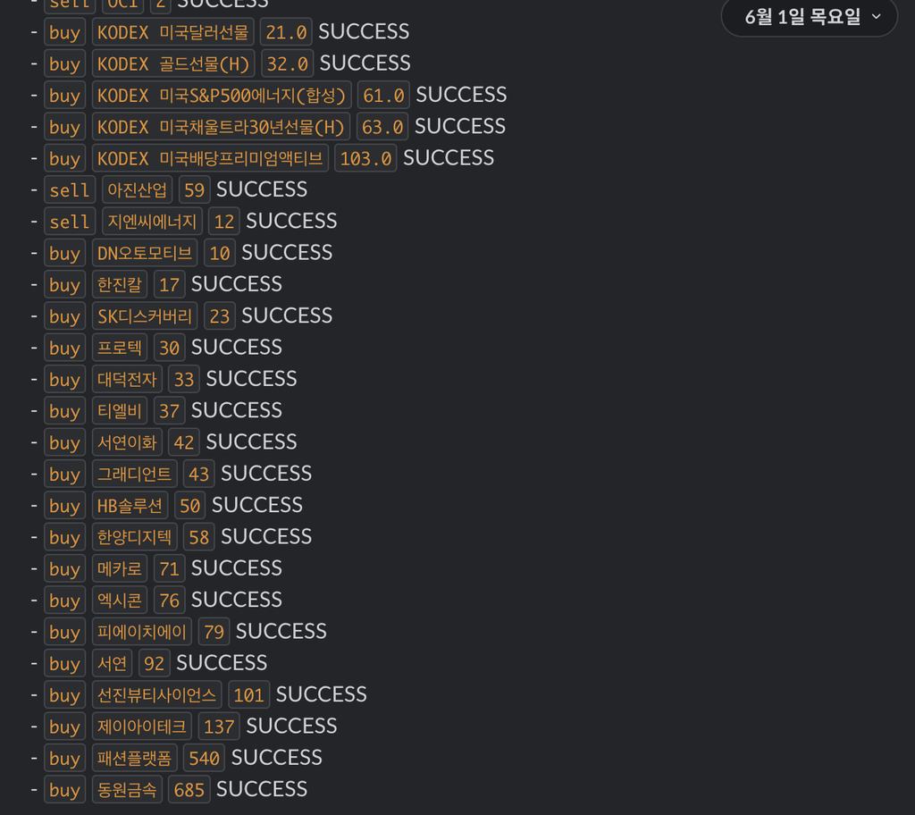

```python
# 6월 보유종목 수익률
_6stocks_df['6_profit'].mean()
```

```
1.1816627521054897
```

```python
# 7월 보유종목
_7stocks_df
```

|  | dt | code | m30 | m30_rank | N | name | OIGR | OIGR_rank | PBR | PBR_rank | ... | ROA | ROA_rank | ROE | ROE_rank | RR | RR_rank | sector | sector_pbr | sector_per | total_rank |
| --- | --- | --- | --- | --- | --- | --- | --- | --- | --- | --- | --- | --- | --- | --- | --- | --- | --- | --- | --- | --- | --- |
| 0 | 20230701 | 39560 | 1.705307 | 4.0 | 438 | 다산네트웍스 | '-203.05 | 394.0 | 0.55 | 77.5 | ... | 30.08 | 5.0 | 70.57 | 3.0 | 2017.1 | 162.0 | 통신장비 | 1.321333 | 30.012667 | 669.5 |
| 1 | 20230701 | 111770 | 1.447081 | 17.0 | 105 | 영원무역 | 85.99 | 95.0 | 0.94 | 194.0 | ... | 18.44 | 25.0 | 26.80 | 28.0 | 12069.7 | 12.0 | "섬유,의류,신발,호화품" | 1.273889 | 11.764444 | 415.0 |
| 2 | 20230701 | 1390 | 1.322114 | 33.0 | 303 | KG케미칼 | 11.8 | 240.0 | 0.73 | 139.5 | ... | 16.06 | 33.0 | 47.97 | 8.0 | 1062.8 | 267.0 | 철강 | 0.765000 | 17.058500 | 725.5 |
| 3 | 20230701 | 353200 | 1.279418 | 40.0 | 169 | 대덕전자 | 220.87 | 48.0 | 1.96 | 341.0 | ... | 17.25 | 31.0 | 23.94 | 44.0 | 3215.6 | 92.0 | 전자장비와기기 | 3.695714 | 65.264643 | 794.0 |
| 4 | 20230701 | 8260 | 1.258641 | 46.0 | 578 | NI스틸 | 117.09 | 72.0 | 1.11 | 233.0 | ... | 13.21 | 54.0 | 29.57 | 23.0 | 1227.2 | 238.0 | 철강 | 0.765000 | 17.058500 | 713.5 |
| 5 | 20230701 | 4430 | 1.254242 | 49.0 | 352 | 송원산업 | 75.11 | 106.0 | 0.71 | 132.0 | ... | 11.31 | 77.0 | 21.53 | 53.0 | 5604.5 | 40.0 | 화학 | 2.787143 | 46.343143 | 519.0 |
| 6 | 20230701 | 36890 | 1.248310 | 55.0 | 283 | 진성티이씨 | 162.2 | 58.0 | 1.21 | 250.5 | ... | 11.90 | 68.0 | 24.04 | 42.0 | 1870.6 | 170.0 | 기계 | 1.367500 | 20.435000 | 718.5 |
| 7 | 20230701 | 1120 | 1.204031 | 78.0 | 176 | LX인터내셔널 | 47.14 | 146.0 | 0.55 | 77.5 | ... | 10.77 | 88.0 | 25.53 | 32.0 | 1066.5 | 266.0 | 무역회사와판매업체 | 0.770000 | 5.130000 | 706.0 |
| 8 | 20230701 | 79960 | 1.203839 | 79.0 | 572 | 동양이엔피 | 87.29 | 94.0 | 0.55 | 77.5 | ... | 6.18 | 187.0 | 8.48 | 240.5 | 7049.5 | 27.0 | 전기제품 | 2.845556 | 30.001111 | 792.0 |
| 9 | 20230701 | 194370 | 1.190876 | 91.0 | 634 | 제이에스코퍼레이션 | 33.63 | 180.0 | 0.71 | 132.0 | ... | 11.89 | 69.0 | 28.26 | 25.0 | 19595.8 | 7.0 | "섬유,의류,신발,호화품" | 1.273889 | 11.764444 | 539.0 |
| 10 | 20230701 | 297890 | 1.179471 | 98.0 | 263 | HB솔루션 | 3962.06 | 4.0 | 2.12 | 355.0 | ... | 23.34 | 8.0 | 35.32 | 15.0 | 1864.9 | 171.0 | 디스플레이장비및부품 | 1.710000 | 13.812308 | 765.0 |
| 11 | 20230701 | 86280 | 1.178269 | 99.0 | 46 | 현대글로비스 | 59.69 | 132.0 | 1.06 | 223.5 | ... | 9.16 | 114.0 | 18.78 | 72.0 | 36441.8 | 4.0 | 항공화물운송과물류 | 0.803333 | 26.646667 | 738.0 |
| 12 | 20230701 | 104830 | 1.150462 | 123.0 | 185 | 원익머트리얼즈 | 75.8 | 105.0 | 0.89 | 180.0 | ... | 11.04 | 82.0 | 13.78 | 134.5 | 6919.2 | 30.0 | 화학 | 2.787143 | 46.343143 | 785.5 |
| 13 | 20230701 | 90470 | 1.145174 | 127.0 | 592 | 제이스텍 | 2625.97 | 5.0 | 0.97 | 201.0 | ... | 15.85 | 34.0 | 20.20 | 60.0 | 1964.9 | 164.0 | 디스플레이장비및부품 | 1.710000 | 13.812308 | 661.0 |
| 14 | 20230701 | 306200 | 1.141006 | 133.0 | 368 | 세아제강 | 63.07 | 123.0 | 0.51 | 59.0 | ... | 11.83 | 70.5 | 21.12 | 58.0 | 5763.2 | 37.0 | 철강 | 0.765000 | 17.058500 | 490.5 |
| 15 | 20230701 | 7340 | 1.140766 | 134.0 | 235 | DN오토모티브 | 370.22 | 34.0 | 0.82 | 162.5 | ... | 6.09 | 191.0 | 22.81 | 49.0 | 23085.5 | 6.0 | 자동차부품 | 0.892273 | 22.822500 | 621.5 |
| 16 | 20230701 | 40610 | 1.123627 | 150.0 | 1196 | SG&G | 451.57 | 24.0 | 0.21 | 6.0 | ... | 11.21 | 81.0 | 14.16 | 128.0 | 1702.9 | 179.0 | 운송인프라 | 0.210000 | 1.490000 | 571.0 |
| 17 | 20230701 | 111110 | 1.123133 | 152.0 | 915 | 호전실업 | 96.83 | 86.0 | 0.50 | 55.5 | ... | 8.65 | 124.5 | 21.24 | 57.0 | 3026.2 | 99.0 | "섬유,의류,신발,호화품" | 1.273889 | 11.764444 | 589.5 |
| 18 | 20230701 | 670 | 1.090092 | 205.0 | 215 | 영풍 | 357.14 | 35.0 | 0.25 | 10.0 | ... | 7.30 | 152.0 | 9.96 | 208.0 | 42518.4 | 3.0 | 핸드셋 | 1.626429 | 16.020000 | 643.0 |
| 19 | 20230701 | 45100 | 1.077296 | 229.0 | 290 | 한양이엔지 | 36.61 | 171.0 | 0.58 | 89.5 | ... | 10.29 | 94.0 | 15.76 | 104.5 | 5197.6 | 49.0 | 건설 | 0.825333 | 27.310667 | 777.0 |

20 rows × 22 columns

- 위 종목을 선택한 기준은 제가 기존에 특성별로 데이터들을 살펴보면서 PER, PBR 등 재무특성데이터중
- 일부 구간을 필터링 해서 제외하는 방식으로 진행하고있습니다.
- 필터링을 통한 방법도 좋은 수익을 얻을 때가 있지만 아직 부족합니다. 조금 더 멋진 방법으로 주식 트레이딩을 할 준비를 하고있습니다.

## MAB(Multi Armed Bandits)

강화학습의 고전적 문제 중 하나로 일정 확률에 의해 보상을 얻을 수 있는 경우 선택을 최적화 하는 문제입니다.

시간의 흐름에 따라 보상을 최대화하는 방법을 찾아내는게 중요하고

컨텐츠들의 추천 알고리즘도 MAB에 기반해서 동작합니다.

유튜브의 알고리즘도 원리 자체는 MAB에 근간을 두고있을거라 생각이듭니다.

공통적으로 강화학습 문제에는 Exploitation(활용)/Exploration(탐험) trade-off 문제가 중요합니다.

활용이란것은 내가 경험에 기반하여 학습한 데이터로 선택에 활용하는것,

탐험은 내가 알고있는것들과 반해 모험적인 선택을 해보는것입니다.

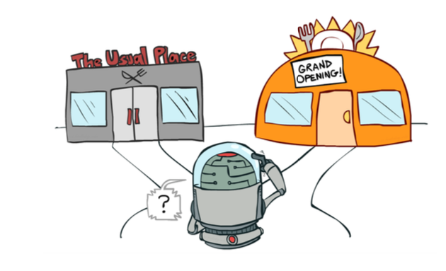

흔히 우리가 자주 다니던 식당과 새로운 식당에 가보는것과 비유하곤합니다.

강화학습에서 Exploitation/Exploration을 어떻게 다루느냐에 따라 여러 방법들이 존재하는데

오늘은 대표적으로 알려진 4가지 정도를 살펴보고

추천에 사용되는 이런 강화학습 로직을

트레이딩에 어떻게 적용할지 이야기해보도록 하겠습니다.

- e-greedy
- softmax exploration
- UCB(Upper confidence Bound) 알고리즘
- Thompson Sampling

```python
import numpy as np
import gym
from gym import spaces
from gym.utils import seeding


class BanditEnv(gym.Env):
    """
    Bandit environment base to allow agents to interact with the class n-armed bandit
    in different variations

    p_dist:
        A list of probabilities of the likelihood that a particular bandit will pay out
    r_dist:
        A list of either rewards (if number) or means and standard deviations (if list)
        of the payout that bandit has
    """
    def __init__(self, p_dist, r_dist):
        if len(p_dist) != len(r_dist):
            raise ValueError("Probability and Reward distribution must be the same length")

        if min(p_dist) < 0 or max(p_dist) > 1:
            raise ValueError("All probabilities must be between 0 and 1")

        for reward in r_dist:
            if isinstance(reward, list) and reward[1] <= 0:
                raise ValueError("Standard deviation in rewards must all be greater than 0")

        self.p_dist = p_dist
        self.r_dist = r_dist

        self.n_bandits = len(p_dist)
        self.action_space = spaces.Discrete(self.n_bandits)
        self.observation_space = spaces.Discrete(1)

        self._seed()

    def _seed(self, seed=None):
        self.np_random, seed = seeding.np_random(seed)
        return [seed]

    def step(self, action):
        assert self.action_space.contains(action)

        reward = 0
        done = True

        if np.random.uniform() < self.p_dist[action]:
            if not isinstance(self.r_dist[action], list):
                reward = self.r_dist[action]
            else:
                reward = np.random.normal(self.r_dist[action][0], self.r_dist[action][1])

        return 0, reward, done, {}

    def reset(self):
        return 0

    def render(self, mode='human', close=False):
        pass

class BanditTenArmedGaussian(BanditEnv):
    """
    10 armed bandit mentioned on page 30 of Sutton and Barto's
    [Reinforcement Learning: An Introduction](https://www.dropbox.com/s/b3psxv2r0ccmf80/book2015oct.pdf?dl=0)

    Actions always pay out
    Mean of payout is pulled from a normal distribution (0, 1) (called q*(a))
    Actual reward is drawn from a normal distribution (q*(a), 1)
    """
    def __init__(self, bandits=10):
        p_dist = np.full(bandits, 1)
        r_dist = []

        for _ in range(bandits):
            r_dist.append([np.random.normal(0, 1), 1])

        BanditEnv.__init__(self, p_dist=p_dist, r_dist=r_dist)
```

```python
import gym
import numpy as np
```

```python
env = BanditTenArmedGaussian()
```

```python
env.action_space
```

```
Discrete(10)
```

예전에도 다루어보았던 gym 라이브러리를 통해서

강화학습 환경을 구현합니다.

여기서는 10개의 선택을 해야하는 환경에 놓이는 경우로 구현을 했습니다.

## e-greedy policy

```python
num_rounds = 20000
count = np.zeros(10)
sum_rewards = np.zeros(10)
Q = np.zeros(10)

def e_greedy(eps):
    rand = np.random.random()
    if rand < eps:
        action = env.action_space.sample()
    else:
        action = np.argmax(Q)
    return action
```

e-greedy 알고리즘에서는 랜덤한 확률 중 epsilon확률 안에서는 랜덤으로 행동하고

```
rand = np.random.random()
|if rand < eps:
    action = env.action_space.sample()
```

그 외에는 가지고있는 행동가치함수 Q에서 최적의 행동을 추출합니다

```
action = np.argmax(Q)
```

```python
env.reset()
for i in range(num_rounds):
    arm = e_greedy(0.5)
    observation, reward, done, info = env.step(arm)
    count[arm] += 1
    sum_rewards[arm] += reward
    Q[arm] = sum_rewards[arm]/count[arm]
print(f'Optimal arm : {np.argmax(Q)}')
```

```
Optimal arm : 7
```

```python
print(Q)
```

```
[-0.11286941  0.45107972 -0.33198331 -0.24017647  0.55740624  0.63721121
  0.95392951  1.84018092 -2.77470303  0.24448561]
```

## Softmax Exploration

```python
num_rounds = 20000
count = np.zeros(10)
sum_rewards = np.zeros(10)
Q = np.zeros(10)

def softmax(tau):
    total = sum([np.exp(val/tau) for val in Q])
    probs = [np.exp(val / tau) / total for val in Q]
    threshold = np.random.random()
    cumulative_prob = 0.0
    for i in range(len(probs)):
        cumulative_prob += probs[i]
        if cumulative_prob > threshold:
            return i
```

소프트맥스 탐험에서는 최적밴딧을 위해 볼츠만 탐험을 합니다.

e-greedy 정책에선 모든 레버를 동등하게 고려했지만

소프트맥스 탐험에서는 레버를 확률적으로 선택합니다.

tau는 temperature factor로 얼마나 많은 수의 레버를 임의로 탐색할 수 있는지를 나타냅니다.

tau가 크면 모든 레버를 동등하게 탐색하고

작으면 높은 보상을 주는 레버만 선택되게됩니다.

```python
env.reset()
for i in range(num_rounds):
    arm = softmax(0.5)
    observation, reward, done, info = env.step(arm)
    count[arm] += 1
    sum_rewards[arm] += reward
    Q[arm] = sum_rewards[arm]/count[arm]
print('The optimal arm is {}'.format(np.argmax(Q)))
```

```
The optimal arm is 7
```

## UCB

위 두 가지방법은 확률에 따라 임의의 행동을 탐험할 수 있었습니다.

Exploration은 다양한 행동을 찾아가는덴 유용하지만

어느정도 학습된 이후에는 무작위성이 강해지게 됩니다.

신뢰상한알고리즘은 불확실성에 대해 낙관적 대응을 하는 알고리즘입니다.

UCB 알고리즘은 신뢰구간에 기반하여 행동들을 판단하고

행동들에 대한 보상의 평균을 계산하여 높은 평균 보상값을 주는 행동을 하는것을 택하는 알고리즘입니다.

```python
# UCB
num_rounds = 20000
count = np.zeros(10)

sum_rewards = np.zeros(10)

Q = np.zeros(10)

def UCB(iters):
    ucb = np.zeros(10)
    if iters < 10:
        return
    else:
        for arm in range(10):
            upper_bound = np.sqrt((2*np.log(sum(count))) / count[arm])
            ucb[arm] = Q[arm] + upper_bound
        return np.argmax(ucb)

env.reset()
for i in range(num_rounds):
    arm = UCB(i)
    if arm is None:
        continue
    observation, reward, done, info = env.step(arm)
    count[arm] += 1
    sum_rewards[arm] += reward
    Q[arm] = sum_rewards[arm] / count[arm]
print('The optimal arm is {}'.format(np.argmax(Q)))
```

```
The optimal arm is 6
```

## Thompson Sampling

TS는 prior distribution에 기반한 확률적 알고리즘입니다.

각 k 행동에 대한 값을 추출하여 이를 사전 평균값으로 사용합니다.

가장 높은 평균 사전 확률값을 갖는 레버를 선택하고 행동한 뒤 보상을 얻습니다.

얻은 보상을 이용하여 사전 분포를 업데이트합니다.

위 과정을 진행하면 사전분포가 참 분포에 점점 가까워집니다.

```python
num_rounds = 20000

count = np.zeros(10)
sum_rewards = np.zeros(10)

Q = np.zeros(10)
# +1 reward count
alpha = np.ones(10)

# -1 reward count
beta = np.ones(10)

def ts(alpha, beta):
    samples = [np.random.beta(alpha[i]+1, beta[i]+1) for i in range(10)]
    return np.argmax(samples)

env.reset()
for i in range(num_rounds):
    arm = ts(alpha, beta)
    observation, reward, done, info = env.step(arm)
    count[arm] += 1
    sum_rewards[arm] += reward
    Q[arm] = sum_rewards[arm] / count[arm]
    if reward > 0:
        alpha[arm] += 1
    else:
        beta[arm] += 1

print('The optimal arm is {}'.format(np.argmax(Q)))
```

```
The optimal arm is 6
```

### 트레이딩과 AI

우리가 트레이딩이라고 한다면

- 한 종목, 예를들어 ETH/USDT 선물포지션을 Long/Short을 유지할지
- 여러 자산군들을 어느비율로 가지고 있을지
- 해당 자산군 소속의 많은 종목 중 어느 것을 선택할지

어느덧 블로그글, 유튜브 작성을 시작한지 1년이 넘어가다보니

위와같은 내용들을 한번씩은 언급을 해본 것 같습니다.

결론적으론 저는 저 3가지 방법을 모두 다 이용할 예정이고 이때 모두 강화학습과 AI알고리즘이 필요합니다.

오늘 다룬 주식의 경우는 3번째 경우에 해당될 것 같습니다.

다르게 생각해본다면 컨텐츠를 제공하는 서비스에서(ex, Youtube)

사용자들이 만족할 컨텐츠를 추천하는것이

시장에서 수익을 얻을 주식을 추천하는것과 비슷하다고 접근했고

추천알고리즘을 이용해서 3번 방법, 주식 트레이딩을 응용해보려고 합니다.

실제로 추천 알고리즘을 주식시장에 적용하기 위한 논문들이 많이있고

서울대학교에서도 해당 연구주제로 논문이 있어서 대충 읽어보기도 했습니다.

하지만 Exploration/Exploitation을 어떻게 할지만 이야기해봤지 아직 감이 오지는 않는 상황입니다.

단순한 Bandit 문제에서 Contextual Bandit, 주어진 상황에서 문맥정보를 고려해서 행동을 선택합니다. 선택하는 알고리즘이

추천알고리즘에서 무작위 추천을 하기보다 사용자별 특성을 고려해서 제시를 해주는게 효과있기 때문이겠죠

주식 트레이딩에서의 Contextual Bandit 알고리즘은 시장의 문맥을 고려해서 추천을 해야합니다.

현재 어떤 종목이 잘나가는 종목이며

기준금리나 경제적인 계절성은 어느 정도이고

종목 개별적인 재무데이터에 기반한것들을 Context화 하고 이용하는게 중요합니다.

### 다음 주식 트레이딩에 이야기해볼것

- Contextual Bandit 알고리즘
- Context에 어떤 데이터들을 담을것인가
- Context를 어떻게 사용할것인가
- Contextual Bandit Trading MVP(Minimum Viable Product) 구현